# CNK 07

D. Bottoli, M. Mlynarczyk, J. Trojgo, A. Sitko

date: 12 - 04 - 2016

### Station description

Station **CNK07** consist of an experiment based on **Stroop effect**.

This effect is shown through a psychological experiment on **two different levels**.

In the first one, the user is asked to press a button of the *same colour* as the word that he is reading.

But what if the word and its colour are *dissociated*?

This happens on the second level: the user has to follow the same procedure but this time it’s much harder.

### Stroop effect

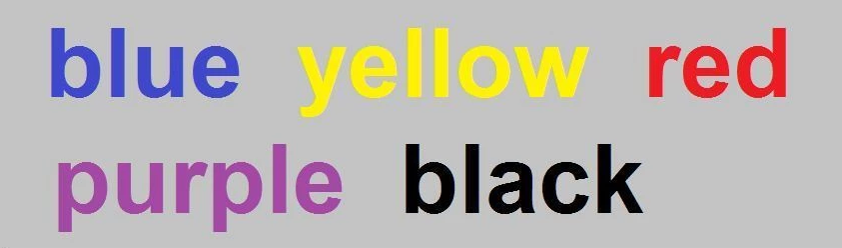

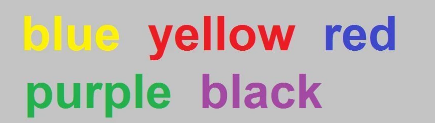

The station is a **two-stage** exhibit. Maybe people can be devided by the number of levels they completed?

Let's try to cluster visitors by scenes' count vectors.

### Scenes

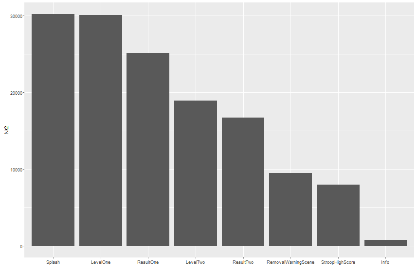

### Results: distribution differences

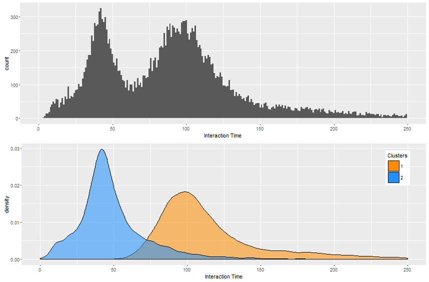

**Note:** histogram is bimodal.

### Results: interest differences

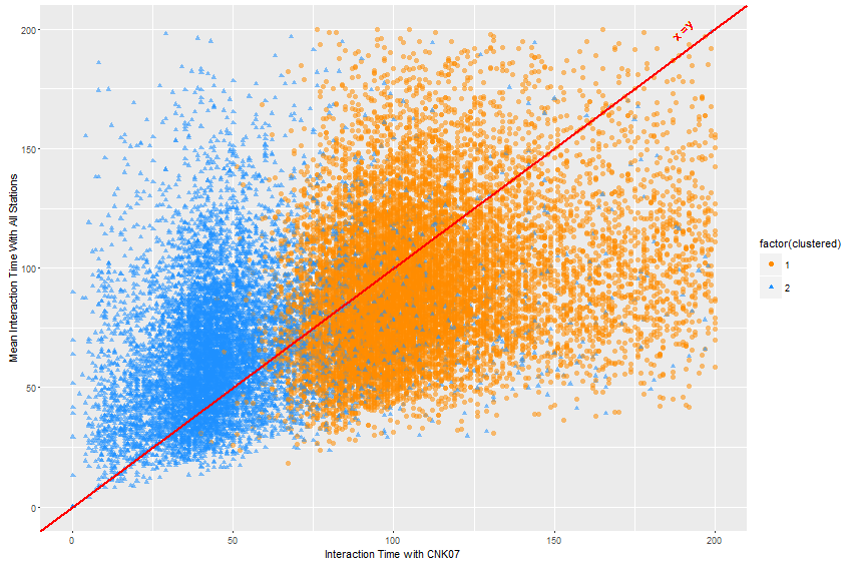

### Results: weekdays interest

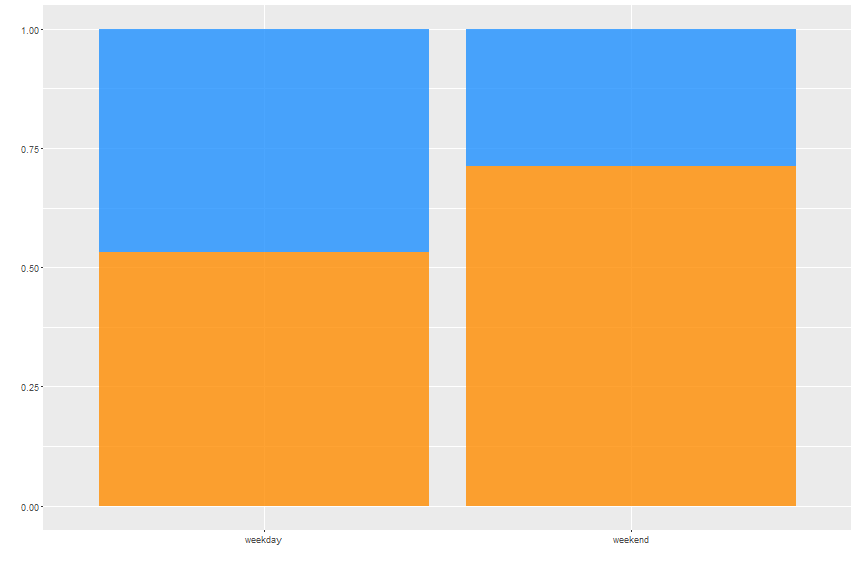

### Results: other differences

**Note:** Orange cluster - people are in general more “active” while inspecting exhibits.

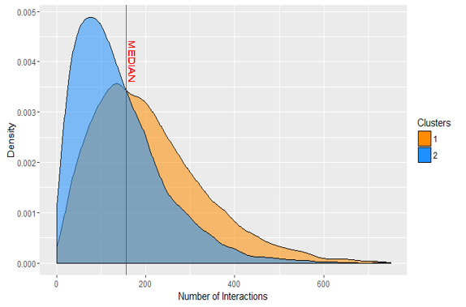

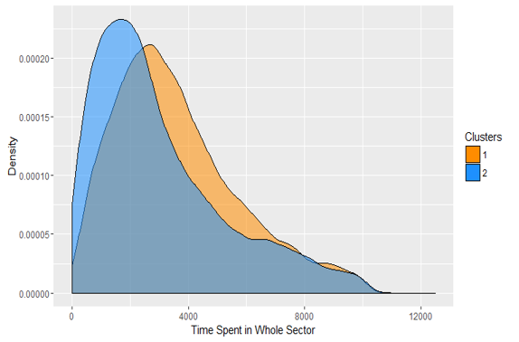

### Numbers

|  | BLUE CLUSTER | ORANGE CLUSTER |
| --- | --- | --- |
| Average time spent at one stations | 68 sec | 97 sec |
| Average time spent at CNK07 | 53 sec | 123 sec |
| Percentage of people that stayed longer at CNK07 than at other stations (on avarage) | 29% | 73% |
| Percentage of weekend-visitors | 23% | 40% |
| Average time spent in the whole sector | 42 minutes | 52 minutes |

Thank you!